# Risk Factor Analysis

## Outcome Variable

**Outcome Variable:** ever_wasted

## Predictor Variables

**Intervention Variable:** perdiar6

**Adjustment Set:**

- arm
- sex
- W_mage
- meducyrs
- feducyrs
- hhwealth_quart
- W_mhtcm
- W_mwtkg
- W_mbmi
- W_birthwt
- W_birthlen
- W_nrooms
- month
- brthmon
- impfloor
- impsan
- safeh20
- delta_W_mage
- delta_meducyrs
- delta_feducyrs
- delta_hhwealth_quart
- delta_W_mhtcm
- delta_W_mwtkg
- delta_W_mbmi
- delta_W_birthwt
- delta_W_birthlen
- delta_W_nrooms
- delta_month
- delta_brthmon
- delta_impfloor
- delta_impsan
- delta_safeh20

## Stratifying Variables

The analysis was stratified on these variable(s):

- agecat
- studyid
- country

## Data Summary

| agecat | studyid | country | perdiar6 | ever_wasted | n_cell | n |
| --- | --- | --- | --- | --- | --- | --- |
| 0-24 months (no birth wast) | CMIN | BANGLADESH | 0% | 0 | 54 | 268 |
| 0-24 months (no birth wast) | CMIN | BANGLADESH | 0% | 1 | 39 | 268 |
| 0-24 months (no birth wast) | CMIN | BANGLADESH | (0%, 5%] | 0 | 40 | 268 |
| 0-24 months (no birth wast) | CMIN | BANGLADESH | (0%, 5%] | 1 | 22 | 268 |
| 0-24 months (no birth wast) | CMIN | BANGLADESH | >5% | 0 | 59 | 268 |
| 0-24 months (no birth wast) | CMIN | BANGLADESH | >5% | 1 | 54 | 268 |
| 0-24 months (no birth wast) | CONTENT | PERU | 0% | 0 | 114 | 215 |
| 0-24 months (no birth wast) | CONTENT | PERU | 0% | 1 | 1 | 215 |
| 0-24 months (no birth wast) | CONTENT | PERU | (0%, 5%] | 0 | 42 | 215 |
| 0-24 months (no birth wast) | CONTENT | PERU | (0%, 5%] | 1 | 1 | 215 |
| 0-24 months (no birth wast) | CONTENT | PERU | >5% | 0 | 55 | 215 |
| 0-24 months (no birth wast) | CONTENT | PERU | >5% | 1 | 2 | 215 |
| 0-24 months (no birth wast) | EE | PAKISTAN | 0% | 0 | 159 | 377 |
| 0-24 months (no birth wast) | EE | PAKISTAN | 0% | 1 | 181 | 377 |
| 0-24 months (no birth wast) | EE | PAKISTAN | (0%, 5%] | 0 | 14 | 377 |
| 0-24 months (no birth wast) | EE | PAKISTAN | (0%, 5%] | 1 | 21 | 377 |
| 0-24 months (no birth wast) | EE | PAKISTAN | >5% | 0 | 1 | 377 |
| 0-24 months (no birth wast) | EE | PAKISTAN | >5% | 1 | 1 | 377 |
| 0-24 months (no birth wast) | MAL-ED | BANGLADESH | 0% | 0 | 65 | 263 |
| 0-24 months (no birth wast) | MAL-ED | BANGLADESH | 0% | 1 | 20 | 263 |
| 0-24 months (no birth wast) | MAL-ED | BANGLADESH | (0%, 5%] | 0 | 75 | 263 |
| 0-24 months (no birth wast) | MAL-ED | BANGLADESH | (0%, 5%] | 1 | 23 | 263 |
| 0-24 months (no birth wast) | MAL-ED | BANGLADESH | >5% | 0 | 65 | 263 |
| 0-24 months (no birth wast) | MAL-ED | BANGLADESH | >5% | 1 | 15 | 263 |
| 0-24 months (no birth wast) | MAL-ED | BRAZIL | 0% | 0 | 205 | 233 |
| 0-24 months (no birth wast) | MAL-ED | BRAZIL | 0% | 1 | 11 | 233 |
| 0-24 months (no birth wast) | MAL-ED | BRAZIL | (0%, 5%] | 0 | 14 | 233 |
| 0-24 months (no birth wast) | MAL-ED | BRAZIL | (0%, 5%] | 1 | 1 | 233 |
| 0-24 months (no birth wast) | MAL-ED | BRAZIL | >5% | 0 | 1 | 233 |
| 0-24 months (no birth wast) | MAL-ED | BRAZIL | >5% | 1 | 1 | 233 |

[output cut: 126 more lines]

The following strata were considered:

- agecat: 0-24 months (no birth wast), studyid: CMIN, country: BANGLADESH
- agecat: 0-24 months (no birth wast), studyid: CONTENT, country: PERU
- agecat: 0-24 months (no birth wast), studyid: EE, country: PAKISTAN
- agecat: 0-24 months (no birth wast), studyid: MAL-ED, country: BANGLADESH
- agecat: 0-24 months (no birth wast), studyid: MAL-ED, country: BRAZIL
- agecat: 0-24 months (no birth wast), studyid: MAL-ED, country: INDIA
- agecat: 0-24 months (no birth wast), studyid: MAL-ED, country: NEPAL
- agecat: 0-24 months (no birth wast), studyid: MAL-ED, country: PERU
- agecat: 0-24 months (no birth wast), studyid: MAL-ED, country: SOUTH AFRICA
- agecat: 0-24 months (no birth wast), studyid: MAL-ED, country: TANZANIA, UNITED REPUBLIC OF
- agecat: 0-24 months (no birth wast), studyid: NIH-Birth, country: BANGLADESH
- agecat: 0-24 months (no birth wast), studyid: NIH-Crypto, country: BANGLADESH
- agecat: 0-24 months (no birth wast), studyid: PROVIDE, country: BANGLADESH
- agecat: 0-6 months (no birth wast), studyid: CMIN, country: BANGLADESH
- agecat: 0-6 months (no birth wast), studyid: CONTENT, country: PERU
- agecat: 0-6 months (no birth wast), studyid: EE, country: PAKISTAN
- agecat: 0-6 months (no birth wast), studyid: MAL-ED, country: BANGLADESH
- agecat: 0-6 months (no birth wast), studyid: MAL-ED, country: BRAZIL
- agecat: 0-6 months (no birth wast), studyid: MAL-ED, country: INDIA
- agecat: 0-6 months (no birth wast), studyid: MAL-ED, country: NEPAL
- agecat: 0-6 months (no birth wast), studyid: MAL-ED, country: PERU
- agecat: 0-6 months (no birth wast), studyid: MAL-ED, country: SOUTH AFRICA
- agecat: 0-6 months (no birth wast), studyid: MAL-ED, country: TANZANIA, UNITED REPUBLIC OF
- agecat: 0-6 months (no birth wast), studyid: NIH-Birth, country: BANGLADESH
- agecat: 0-6 months (no birth wast), studyid: NIH-Crypto, country: BANGLADESH
- agecat: 0-6 months (no birth wast), studyid: PROVIDE, country: BANGLADESH

### Dropped Strata

Some strata were dropped due to rare outcomes:

- agecat: 0-24 months (no birth wast), studyid: CONTENT, country: PERU
- agecat: 0-24 months (no birth wast), studyid: EE, country: PAKISTAN
- agecat: 0-24 months (no birth wast), studyid: MAL-ED, country: BRAZIL
- agecat: 0-24 months (no birth wast), studyid: MAL-ED, country: SOUTH AFRICA
- agecat: 0-24 months (no birth wast), studyid: MAL-ED, country: TANZANIA, UNITED REPUBLIC OF
- agecat: 0-6 months (no birth wast), studyid: CONTENT, country: PERU
- agecat: 0-6 months (no birth wast), studyid: EE, country: PAKISTAN
- agecat: 0-6 months (no birth wast), studyid: MAL-ED, country: BRAZIL
- agecat: 0-6 months (no birth wast), studyid: MAL-ED, country: NEPAL
- agecat: 0-6 months (no birth wast), studyid: MAL-ED, country: PERU
- agecat: 0-6 months (no birth wast), studyid: MAL-ED, country: SOUTH AFRICA
- agecat: 0-6 months (no birth wast), studyid: MAL-ED, country: TANZANIA, UNITED REPUBLIC OF

## Methods Detail

We're interested in the causal parameters $E[Y_a]$ for all values of $a \in \mathcal{A}$. These parameters represent the mean outcome if, possibly contrary to fact, we intervened to set all units to have $A=a$. Under the randomization and positivity assumptions, these are identified by the statistical parameters $\psi_a=E_W[E_{Y|A,W}(Y|A=a,W)]$. In addition, we're interested in the mean of $Y$, $E[Y]$ under no intervention (the observed mean). We will estimate these parameters by using SuperLearner to fit the relevant likelihood factors -- $E_{Y|A,W}(Y|A=a,W)$ and $p(A=a|W)$, and then updating our likelihood fit using a joint TMLE.

For unadjusted analyses ($W=\{\}$), initial likelihoods were estimated using Lrnr_glm to estimate the simple $E(Y|A)$ and Lrnr_mean to estimate $p(A)$. For adjusted analyses, a small library containing Lrnr_glmnet, Lrnr_xgboost, and Lrnr_mean was used.

Having estimated these parameters, we will then use the delta method to estimate relative risks and attributable risks relative to a prespecified baseline level of $A$.

# Results Detail

## Results Plots

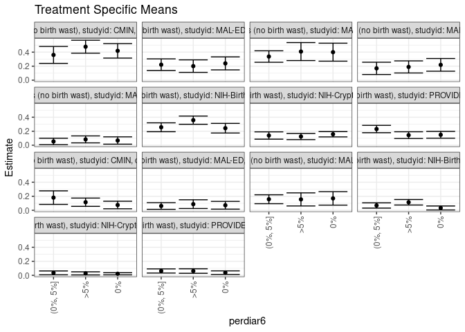

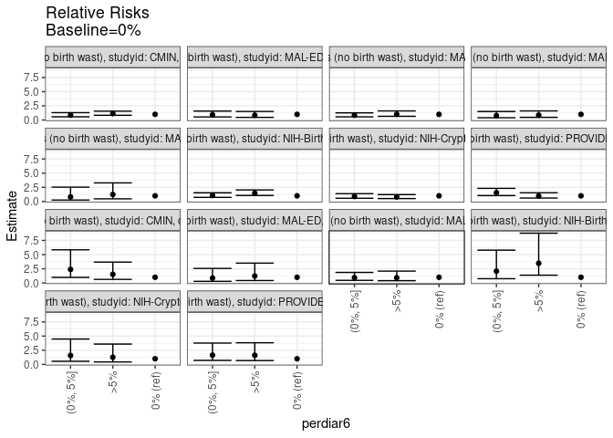

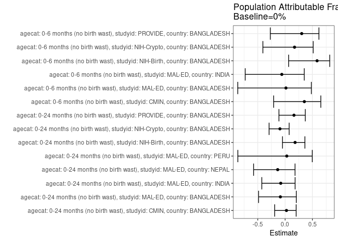

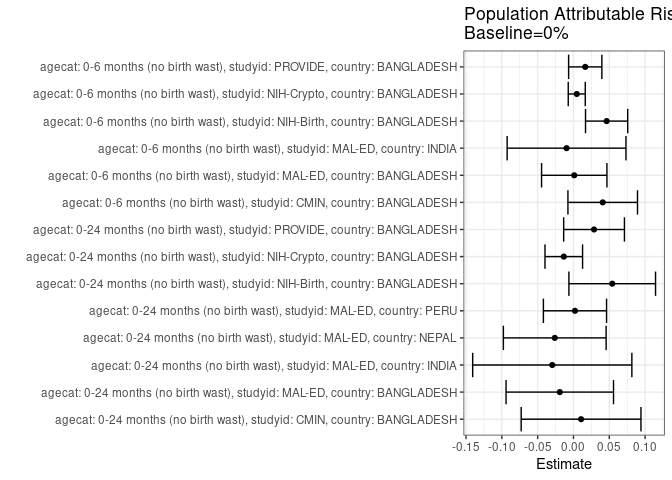

## Results Table

### Parameter: TSM

| agecat | studyid | country | intervention_level | baseline_level | estimate | ci_lower | ci_upper |
| --- | --- | --- | --- | --- | --- | --- | --- |
| 0-24 months (no birth wast) | CMIN | BANGLADESH | 0% | NA | 0.4184858 | 0.3154635 | 0.5215081 |
| 0-24 months (no birth wast) | CMIN | BANGLADESH | (0%, 5%] | NA | 0.3601410 | 0.2392691 | 0.4810130 |
| 0-24 months (no birth wast) | CMIN | BANGLADESH | >5% | NA | 0.4770335 | 0.3843835 | 0.5696834 |
| 0-24 months (no birth wast) | MAL-ED | BANGLADESH | 0% | NA | 0.2396150 | 0.1471624 | 0.3320676 |
| 0-24 months (no birth wast) | MAL-ED | BANGLADESH | (0%, 5%] | NA | 0.2210045 | 0.1380412 | 0.3039678 |
| 0-24 months (no birth wast) | MAL-ED | BANGLADESH | >5% | NA | 0.2006182 | 0.1114440 | 0.2897925 |
| 0-24 months (no birth wast) | MAL-ED | INDIA | 0% | NA | 0.3994996 | 0.2713046 | 0.5276947 |
| 0-24 months (no birth wast) | MAL-ED | INDIA | (0%, 5%] | NA | 0.3374187 | 0.2554982 | 0.4193392 |
| 0-24 months (no birth wast) | MAL-ED | INDIA | >5% | NA | 0.4081526 | 0.2798845 | 0.5364208 |
| 0-24 months (no birth wast) | MAL-ED | NEPAL | 0% | NA | 0.2185887 | 0.1279278 | 0.3092496 |
| 0-24 months (no birth wast) | MAL-ED | NEPAL | (0%, 5%] | NA | 0.1687851 | 0.0814453 | 0.2561250 |
| 0-24 months (no birth wast) | MAL-ED | NEPAL | >5% | NA | 0.1890848 | 0.1027953 | 0.2753742 |
| 0-24 months (no birth wast) | MAL-ED | PERU | 0% | NA | 0.0674157 | 0.0152365 | 0.1195950 |
| 0-24 months (no birth wast) | MAL-ED | PERU | (0%, 5%] | NA | 0.0537634 | 0.0078468 | 0.0996801 |
| 0-24 months (no birth wast) | MAL-ED | PERU | >5% | NA | 0.0833333 | 0.0338005 | 0.1328661 |
| 0-24 months (no birth wast) | NIH-Birth | BANGLADESH | 0% | NA | 0.2430399 | 0.1745139 | 0.3115659 |
| 0-24 months (no birth wast) | NIH-Birth | BANGLADESH | (0%, 5%] | NA | 0.2563061 | 0.1929462 | 0.3196660 |
| 0-24 months (no birth wast) | NIH-Birth | BANGLADESH | >5% | NA | 0.3572897 | 0.2988405 | 0.4157390 |
| 0-24 months (no birth wast) | NIH-Crypto | BANGLADESH | 0% | NA | 0.1567507 | 0.1190920 | 0.1944093 |
| 0-24 months (no birth wast) | NIH-Crypto | BANGLADESH | (0%, 5%] | NA | 0.1387726 | 0.0866473 | 0.1908979 |
| 0-24 months (no birth wast) | NIH-Crypto | BANGLADESH | >5% | NA | 0.1240981 | 0.0801591 | 0.1680370 |
| 0-24 months (no birth wast) | PROVIDE | BANGLADESH | 0% | NA | 0.1488453 | 0.1000311 | 0.1976595 |
| 0-24 months (no birth wast) | PROVIDE | BANGLADESH | (0%, 5%] | NA | 0.2311666 | 0.1786427 | 0.2836904 |
| 0-24 months (no birth wast) | PROVIDE | BANGLADESH | >5% | NA | 0.1439277 | 0.0959695 | 0.1918860 |
| 0-6 months (no birth wast) | CMIN | BANGLADESH | 0% | NA | 0.0752688 | 0.0215487 | 0.1289889 |
| 0-6 months (no birth wast) | CMIN | BANGLADESH | (0%, 5%] | NA | 0.1803279 | 0.0836673 | 0.2769885 |
| 0-6 months (no birth wast) | CMIN | BANGLADESH | >5% | NA | 0.1150442 | 0.0561033 | 0.1739852 |
| 0-6 months (no birth wast) | MAL-ED | BANGLADESH | 0% | NA | 0.0714286 | 0.0162485 | 0.1266087 |
| 0-6 months (no birth wast) | MAL-ED | BANGLADESH | (0%, 5%] | NA | 0.0612245 | 0.0136681 | 0.1087809 |
| 0-6 months (no birth wast) | MAL-ED | BANGLADESH | >5% | NA | 0.0875000 | 0.0254625 | 0.1495375 |
| 0-6 months (no birth wast) | MAL-ED | INDIA | 0% | NA | 0.1694915 | 0.0735603 | 0.2654227 |
| 0-6 months (no birth wast) | MAL-ED | INDIA | (0%, 5%] | NA | 0.1574803 | 0.0939997 | 0.2209609 |
| 0-6 months (no birth wast) | MAL-ED | INDIA | >5% | NA | 0.1551724 | 0.0618003 | 0.2485445 |
| 0-6 months (no birth wast) | NIH-Birth | BANGLADESH | 0% | NA | 0.0328947 | 0.0045155 | 0.0612740 |
| 0-6 months (no birth wast) | NIH-Birth | BANGLADESH | (0%, 5%] | NA | 0.0685714 | 0.0310957 | 0.1060471 |
| 0-6 months (no birth wast) | NIH-Birth | BANGLADESH | >5% | NA | 0.1141732 | 0.0750295 | 0.1533169 |
| 0-6 months (no birth wast) | NIH-Crypto | BANGLADESH | 0% | NA | 0.0220994 | 0.0069456 | 0.0372533 |
| 0-6 months (no birth wast) | NIH-Crypto | BANGLADESH | (0%, 5%] | NA | 0.0348837 | 0.0074443 | 0.0623232 |
| 0-6 months (no birth wast) | NIH-Crypto | BANGLADESH | >5% | NA | 0.0279070 | 0.0058762 | 0.0499377 |
| 0-6 months (no birth wast) | PROVIDE | BANGLADESH | 0% | NA | 0.0377358 | 0.0120660 | 0.0634057 |
| 0-6 months (no birth wast) | PROVIDE | BANGLADESH | (0%, 5%] | NA | 0.0620155 | 0.0325642 | 0.0914668 |
| 0-6 months (no birth wast) | PROVIDE | BANGLADESH | >5% | NA | 0.0610329 | 0.0288605 | 0.0932053 |

### Parameter: E(Y)

| agecat | studyid | country | intervention_level | baseline_level | estimate | ci_lower | ci_upper |
| --- | --- | --- | --- | --- | --- | --- | --- |
| 0-24 months (no birth wast) | CMIN | BANGLADESH | NA | NA | 0.4291045 | 0.3697365 | 0.4884725 |
| 0-24 months (no birth wast) | MAL-ED | BANGLADESH | NA | NA | 0.2205323 | 0.1703290 | 0.2707357 |
| 0-24 months (no birth wast) | MAL-ED | INDIA | NA | NA | 0.3699187 | 0.3094659 | 0.4303715 |
| 0-24 months (no birth wast) | MAL-ED | NEPAL | NA | NA | 0.1924686 | 0.1423823 | 0.2425550 |
| 0-24 months (no birth wast) | MAL-ED | PERU | NA | NA | 0.0695364 | 0.0408008 | 0.0982721 |
| 0-24 months (no birth wast) | NIH-Birth | BANGLADESH | NA | NA | 0.2971619 | 0.2605332 | 0.3337907 |
| 0-24 months (no birth wast) | NIH-Crypto | BANGLADESH | NA | NA | 0.1432361 | 0.1182149 | 0.1682572 |
| 0-24 months (no birth wast) | PROVIDE | BANGLADESH | NA | NA | 0.1775837 | 0.1489858 | 0.2061816 |
| 0-6 months (no birth wast) | CMIN | BANGLADESH | NA | NA | 0.1161049 | 0.0776073 | 0.1546024 |
| 0-6 months (no birth wast) | MAL-ED | BANGLADESH | NA | NA | 0.0725191 | 0.0410556 | 0.1039825 |
| 0-6 months (no birth wast) | MAL-ED | INDIA | NA | NA | 0.1598361 | 0.1137612 | 0.2059110 |
| 0-6 months (no birth wast) | NIH-Birth | BANGLADESH | NA | NA | 0.0791738 | 0.0571996 | 0.1011481 |
| 0-6 months (no birth wast) | NIH-Crypto | BANGLADESH | NA | NA | 0.0267023 | 0.0151493 | 0.0382553 |
| 0-6 months (no birth wast) | PROVIDE | BANGLADESH | NA | NA | 0.0541728 | 0.0371844 | 0.0711612 |

### Parameter: RR

| agecat | studyid | country | intervention_level | baseline_level | estimate | ci_lower | ci_upper |
| --- | --- | --- | --- | --- | --- | --- | --- |
| 0-24 months (no birth wast) | CMIN | BANGLADESH | 0% | 0% | 1.0000000 | 1.0000000 | 1.000000 |
| 0-24 months (no birth wast) | CMIN | BANGLADESH | (0%, 5%] | 0% | 0.8605813 | 0.5676708 | 1.304630 |
| 0-24 months (no birth wast) | CMIN | BANGLADESH | >5% | 0% | 1.1399037 | 0.8326427 | 1.560550 |
| 0-24 months (no birth wast) | MAL-ED | BANGLADESH | 0% | 0% | 1.0000000 | 1.0000000 | 1.000000 |
| 0-24 months (no birth wast) | MAL-ED | BANGLADESH | (0%, 5%] | 0% | 0.9223316 | 0.5405120 | 1.573870 |
| 0-24 months (no birth wast) | MAL-ED | BANGLADESH | >5% | 0% | 0.8372523 | 0.4661414 | 1.503817 |
| 0-24 months (no birth wast) | MAL-ED | INDIA | 0% | 0% | 1.0000000 | 1.0000000 | 1.000000 |
| 0-24 months (no birth wast) | MAL-ED | INDIA | (0%, 5%] | 0% | 0.8446034 | 0.5644805 | 1.263737 |
| 0-24 months (no birth wast) | MAL-ED | INDIA | >5% | 0% | 1.0216596 | 0.6518079 | 1.601374 |
| 0-24 months (no birth wast) | MAL-ED | NEPAL | 0% | 0% | 1.0000000 | 1.0000000 | 1.000000 |
| 0-24 months (no birth wast) | MAL-ED | NEPAL | (0%, 5%] | 0% | 0.7721587 | 0.3976020 | 1.499562 |
| 0-24 months (no birth wast) | MAL-ED | NEPAL | >5% | 0% | 0.8650255 | 0.4679413 | 1.599066 |
| 0-24 months (no birth wast) | MAL-ED | PERU | 0% | 0% | 1.0000000 | 1.0000000 | 1.000000 |
| 0-24 months (no birth wast) | MAL-ED | PERU | (0%, 5%] | 0% | 0.7974910 | 0.2518616 | 2.525164 |
| 0-24 months (no birth wast) | MAL-ED | PERU | >5% | 0% | 1.2361111 | 0.4658353 | 3.280066 |
| 0-24 months (no birth wast) | NIH-Birth | BANGLADESH | 0% | 0% | 1.0000000 | 1.0000000 | 1.000000 |
| 0-24 months (no birth wast) | NIH-Birth | BANGLADESH | (0%, 5%] | 0% | 1.0545848 | 0.7250083 | 1.533981 |
| 0-24 months (no birth wast) | NIH-Birth | BANGLADESH | >5% | 0% | 1.4700871 | 1.0620931 | 2.034808 |
| 0-24 months (no birth wast) | NIH-Crypto | BANGLADESH | 0% | 0% | 1.0000000 | 1.0000000 | 1.000000 |
| 0-24 months (no birth wast) | NIH-Crypto | BANGLADESH | (0%, 5%] | 0% | 0.8853080 | 0.5668677 | 1.382634 |
| 0-24 months (no birth wast) | NIH-Crypto | BANGLADESH | >5% | 0% | 0.7916909 | 0.5160407 | 1.214583 |
| 0-24 months (no birth wast) | PROVIDE | BANGLADESH | 0% | 0% | 1.0000000 | 1.0000000 | 1.000000 |
| 0-24 months (no birth wast) | PROVIDE | BANGLADESH | (0%, 5%] | 0% | 1.5530658 | 1.0415304 | 2.315836 |
| 0-24 months (no birth wast) | PROVIDE | BANGLADESH | >5% | 0% | 0.9669618 | 0.6055675 | 1.544031 |
| 0-6 months (no birth wast) | CMIN | BANGLADESH | 0% | 0% | 1.0000000 | 1.0000000 | 1.000000 |
| 0-6 months (no birth wast) | CMIN | BANGLADESH | (0%, 5%] | 0% | 2.3957845 | 0.9813036 | 5.849142 |
| 0-6 months (no birth wast) | CMIN | BANGLADESH | >5% | 0% | 1.5284450 | 0.6348869 | 3.679622 |
| 0-6 months (no birth wast) | MAL-ED | BANGLADESH | 0% | 0% | 1.0000000 | 1.0000000 | 1.000000 |
| 0-6 months (no birth wast) | MAL-ED | BANGLADESH | (0%, 5%] | 0% | 0.8571429 | 0.2866027 | 2.563457 |
| 0-6 months (no birth wast) | MAL-ED | BANGLADESH | >5% | 0% | 1.2250000 | 0.4292932 | 3.495571 |
| 0-6 months (no birth wast) | MAL-ED | INDIA | 0% | 0% | 1.0000000 | 1.0000000 | 1.000000 |
| 0-6 months (no birth wast) | MAL-ED | INDIA | (0%, 5%] | 0% | 0.9291339 | 0.4637685 | 1.861467 |
| 0-6 months (no birth wast) | MAL-ED | INDIA | >5% | 0% | 0.9155172 | 0.4007733 | 2.091386 |
| 0-6 months (no birth wast) | NIH-Birth | BANGLADESH | 0% | 0% | 1.0000000 | 1.0000000 | 1.000000 |
| 0-6 months (no birth wast) | NIH-Birth | BANGLADESH | (0%, 5%] | 0% | 2.0845714 | 0.7507348 | 5.788247 |
| 0-6 months (no birth wast) | NIH-Birth | BANGLADESH | >5% | 0% | 3.4708661 | 1.3716980 | 8.782481 |
| 0-6 months (no birth wast) | NIH-Crypto | BANGLADESH | 0% | 0% | 1.0000000 | 1.0000000 | 1.000000 |
| 0-6 months (no birth wast) | NIH-Crypto | BANGLADESH | (0%, 5%] | 0% | 1.5784884 | 0.5559638 | 4.481633 |
| 0-6 months (no birth wast) | NIH-Crypto | BANGLADESH | >5% | 0% | 1.2627907 | 0.4438198 | 3.592990 |
| 0-6 months (no birth wast) | PROVIDE | BANGLADESH | 0% | 0% | 1.0000000 | 1.0000000 | 1.000000 |
| 0-6 months (no birth wast) | PROVIDE | BANGLADESH | (0%, 5%] | 0% | 1.6434109 | 0.7168794 | 3.767438 |
| 0-6 months (no birth wast) | PROVIDE | BANGLADESH | >5% | 0% | 1.6173709 | 0.6840090 | 3.824348 |

### Parameter: PAR

| agecat | studyid | country | intervention_level | baseline_level | estimate | ci_lower | ci_upper |
| --- | --- | --- | --- | --- | --- | --- | --- |
| 0-24 months (no birth wast) | CMIN | BANGLADESH | 0% | NA | 0.0106187 | -0.0729876 | 0.0942250 |
| 0-24 months (no birth wast) | MAL-ED | BANGLADESH | 0% | NA | -0.0190827 | -0.0940822 | 0.0559168 |
| 0-24 months (no birth wast) | MAL-ED | INDIA | 0% | NA | -0.0295809 | -0.1406876 | 0.0815257 |
| 0-24 months (no birth wast) | MAL-ED | NEPAL | 0% | NA | -0.0261201 | -0.0978352 | 0.0455951 |
| 0-24 months (no birth wast) | MAL-ED | PERU | 0% | NA | 0.0021207 | -0.0419662 | 0.0462076 |
| 0-24 months (no birth wast) | NIH-Birth | BANGLADESH | 0% | NA | 0.0541221 | -0.0063462 | 0.1145903 |
| 0-24 months (no birth wast) | NIH-Crypto | BANGLADESH | 0% | NA | -0.0135146 | -0.0397403 | 0.0127111 |
| 0-24 months (no birth wast) | PROVIDE | BANGLADESH | 0% | NA | 0.0287384 | -0.0136762 | 0.0711529 |
| 0-6 months (no birth wast) | CMIN | BANGLADESH | 0% | NA | 0.0408361 | -0.0077185 | 0.0893906 |
| 0-6 months (no birth wast) | MAL-ED | BANGLADESH | 0% | NA | 0.0010905 | -0.0445425 | 0.0467235 |
| 0-6 months (no birth wast) | MAL-ED | INDIA | 0% | NA | -0.0096555 | -0.0925720 | 0.0732611 |
| 0-6 months (no birth wast) | NIH-Birth | BANGLADESH | 0% | NA | 0.0462791 | 0.0168369 | 0.0757213 |
| 0-6 months (no birth wast) | NIH-Crypto | BANGLADESH | 0% | NA | 0.0046028 | -0.0072773 | 0.0164829 |
| 0-6 months (no birth wast) | PROVIDE | BANGLADESH | 0% | NA | 0.0164369 | -0.0067683 | 0.0396421 |

### Parameter: PAF

| agecat | studyid | country | intervention_level | baseline_level | estimate | ci_lower | ci_upper |
| --- | --- | --- | --- | --- | --- | --- | --- |
| 0-24 months (no birth wast) | CMIN | BANGLADESH | 0% | NA | 0.0247462 | -0.1909976 | 0.2014089 |
| 0-24 months (no birth wast) | MAL-ED | BANGLADESH | 0% | NA | -0.0865302 | -0.4851947 | 0.2051224 |
| 0-24 months (no birth wast) | MAL-ED | INDIA | 0% | NA | -0.0799661 | -0.4260605 | 0.1821338 |
| 0-24 months (no birth wast) | MAL-ED | NEPAL | 0% | NA | -0.1357107 | -0.5751590 | 0.1811374 |
| 0-24 months (no birth wast) | MAL-ED | PERU | 0% | NA | 0.0304976 | -0.8642767 | 0.4958179 |
| 0-24 months (no birth wast) | NIH-Birth | BANGLADESH | 0% | NA | 0.1821299 | -0.0485297 | 0.3620482 |
| 0-24 months (no birth wast) | NIH-Crypto | BANGLADESH | 0% | NA | -0.0943518 | -0.2929813 | 0.0737640 |
| 0-24 months (no birth wast) | PROVIDE | BANGLADESH | 0% | NA | 0.1618301 | -0.1130644 | 0.3688336 |
| 0-6 months (no birth wast) | CMIN | BANGLADESH | 0% | NA | 0.3517170 | -0.2098491 | 0.6526254 |
| 0-6 months (no birth wast) | MAL-ED | BANGLADESH | 0% | NA | 0.0150376 | -0.8657846 | 0.4800306 |
| 0-6 months (no birth wast) | MAL-ED | INDIA | 0% | NA | -0.0604085 | -0.7292670 | 0.3497440 |
| 0-6 months (no birth wast) | NIH-Birth | BANGLADESH | 0% | NA | 0.5845252 | 0.0640759 | 0.8155627 |
| 0-6 months (no birth wast) | NIH-Crypto | BANGLADESH | 0% | NA | 0.1723757 | -0.4065203 | 0.5130095 |
| 0-6 months (no birth wast) | PROVIDE | BANGLADESH | 0% | NA | 0.3034166 | -0.2702928 | 0.6180185 |